# Basic Inferential Data Analysis

Khoa Tran

04/08/2020

# Overview

In the second part, we are going to explore the ToothGrowth dataset and use confidence intervals and/or hypothesis tests to compare tooth growth by supp and dose.

## Part 2

Load the needed library

```r
library(ggplot2)
```

In this second part, we will work with the ToothGrowth dataset

```r
str(ToothGrowth)
```

```
## 'data.frame':    60 obs. of  3 variables:
##  $ len : num  4.2 11.5 7.3 5.8 6.4 10 11.2 11.2 5.2 7 ...
##  $ supp: Factor w/ 2 levels "OJ","VC": 2 2 2 2 2 2 2 2 2 2 ...
##  $ dose: num  0.5 0.5 0.5 0.5 0.5 0.5 0.5 0.5 0.5 0.5 ...
```

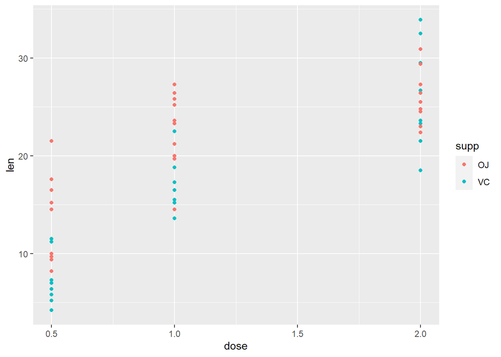

```r
ggplot(ToothGrowth, aes(dose,len)) + geom_point(aes(col = supp))
```

As the can see, there seem to be differences between 2 type of supplementary at different dose level. We will perform hypothesis tests to confirm this.

```r
OJ <- subset(ToothGrowth, supp == "OJ")
VC <- subset(ToothGrowth, supp == "VC")
```

#### OJ vs VC at the 0.5 dose level

```r
OJ_0.5 <- subset(OJ, dose == 0.5)
VC_0.5 <- subset(VC,dose == 0.5)
```

First we let check the len firgure has the same variance or not

```r
sd(OJ_0.5$len)^2 / sd(VC_0.5$len)^2
```

```
## [1] 2.6364
```

As this is about 2.6 we can asume that they do not have the same variance

Perform the t-test

```r
t.test(OJ_0.5$len,VC_0.5$len,paired = FALSE, var.equal = FALSE ,alternative = "greater")
```

```
##
##  Welch Two Sample t-test
##
## data:  OJ_0.5$len and VC_0.5$len
## t = 3.1697, df = 14.969, p-value = 0.003179
## alternative hypothesis: true difference in means is greater than 0
## 95 percent confidence interval:
##  2.34604     Inf
## sample estimates:
## mean of x mean of y
##     13.23      7.98
```

As the p-values is 0.003179 is lower that our significant level 0.05 . Therefore , we can reject the null hypothesis. And it is very likely that OJ at this dose level is more effective that VC

#### OJ vs VC at the 1 dose level

```r
OJ_1 <- subset(OJ, dose == 1)
VC_1 <- subset(VC,dose == 1)
```

First we let check the len firgure has the same variance or not

```r
sd(OJ_1$len)^2 / sd(VC_1$len)^2
```

```
## [1] 2.41759
```

As this is about 2.4 we can asume that they do not have the same variance

Perform the t-test

```r
t.test(OJ_1$len,VC_1$len,paired = FALSE, var.equal = FALSE, alternative = "greater")
```

```
##
##  Welch Two Sample t-test
##
## data:  OJ_1$len and VC_1$len
## t = 4.0328, df = 15.358, p-value = 0.0005192
## alternative hypothesis: true difference in means is greater than 0
## 95 percent confidence interval:
##  3.356158      Inf
## sample estimates:
## mean of x mean of y
##     22.70     16.77
```

As the p-values is 0.0005192 is lower that our significant level 0.05 . Therefore , we can reject the null hypothesis. And it is very likely that OJ at this dose level is more effective that VC

#### OJ vs VC at the 2 dose level

```r
OJ_2 <- subset(OJ, dose == 2)
VC_2 <- subset(VC,dose == 2)
```

First we let check the len firgure has the same variance or not

```r
sd(OJ_2$len)^2 / sd(VC_2$len)^2
```

```
## [1] 0.3062501
```

Perform the t-test

```r
t.test(OJ_2$len,VC_2$len,paired = FALSE, var.equal = TRUE, alternative = "greater")
```

```
##
##  Two Sample t-test
##
## data:  OJ_2$len and VC_2$len
## t = -0.046136, df = 18, p-value = 0.5181
## alternative hypothesis: true difference in means is greater than 0
## 95 percent confidence interval:
##  -3.086866       Inf
## sample estimates:
## mean of x mean of y
##     26.06     26.14
```

As the p-values is 0.5181 is larger that our significant level 0.05 . Therefore , we are fail to reject the null hypothesis.

### Conclusion

In the first 2 dose level, 0.5 and 1, there are a reasonable evidence to state that the OJ help to growth better than VC. However, at the 2 dose level, there are not enough evidence to conclude the samething, and we have to assume there are no difference between them.

### Assumptions

- The data is collect randomly without any bias
- The data is independence with the sample size < 10% of the population
- The parent population is normally distributed